# RNAseqHW

Manpreet S. Katari

### Data source

The data was downloaded from NCBI GEO (GSE124548). The study looks at the affect of a drug (Lumacaftor/Ivacaftor) to treat cystic fibrosis ( CF ). This drug has been approved for individuals that are homozygous for CFTR ( Cystic fibrosis transmembrane conductance regulator ) mutation. Clinical studies have observed that there is a large variation in the response thus the researchers are looking at RNA expressions to help identify the cause of this variation. Blood samples were taken from : - 20 healthy patients ( do not have CF ) - 20 patients that CF ( before treatment ) - 20 patients that have CF ( after treatment - these are paired with those before treatment)

I have extracted the raw read counts from the original matrix and provided it with the homework. The healthy patients have “HC” in their names, CF patients before treatment are labeled “Base” and after treatment are labeled “V2”.

For the homework we will compare the HC with Base to do a simple unpaired differentially expression.

### Step 1 (5pts)

Load the file **GSE124548.raw.txt** and create a new dataframe with just the columns with the raw counts for healthy (HC) and CF patients before treatment (Base) and call it **readcount**. Use the *third* column (EntrezID) in the original file as the rownames of readcount.

```r
df = read.delim('GSE124548.raw.fixed.txt', sep = '\t')
readcount = data.frame(select(df,contains("HC"),contains("Base")), row.names = df$EntrezID)
#
```

### Step 2 (5pts)

Create a dataframe, called **expgroup**, with one column, labeled **condition**, that correctly assigns which column is healthy and which is CF. Use the column names of readount as rownames of expgroup.

```r
colnames = colnames(readcount)
condition_vec = c()
for (line in colnames)
{
  if (str_detect(line,'HC'))
  {
    condition_vec = append(condition_vec,'Healthy')
  }
  else
  {
    condition_vec = append(condition_vec,'CF')
  }
}
expgroup = data.frame(condition_vec,row.names = colnames)
head(expgroup)
```

```
##                        condition_vec
## Raw_10_HC_Auto_066_237       Healthy
## Raw_13_HC_Auto_068_239       Healthy
## Raw_16_HC_Auto_072_243       Healthy
## Raw_19_HC_Auto_074_245       Healthy
## Raw_21_HC_Immune_004         Healthy
## Raw_23_HC_Auto_076_247       Healthy
```

### Step 3 (5pts)

Load the Deseq2 package ( install if necessary ) and create a Counts Dataset Matrix using the command **DESeqDataSetFromMatrix()** and call it **cds**.

```r
library('DESeq2')
cds = DESeqDataSetFromMatrix(design= ~ condition_vec, countData = readcount, colData = expgroup)
```

### Step 4 (5pts)

Use the functions **estimateSizeFactors** and **estimateDispersions** so that Deseq2 can correct for size of library and estimates the dispersion. Plot the dispersion using **plotDispEsts**. What does the graph tell you?

```r
cds = estimateSizeFactors(cds)
cds = estimateDispersions(cds)
```

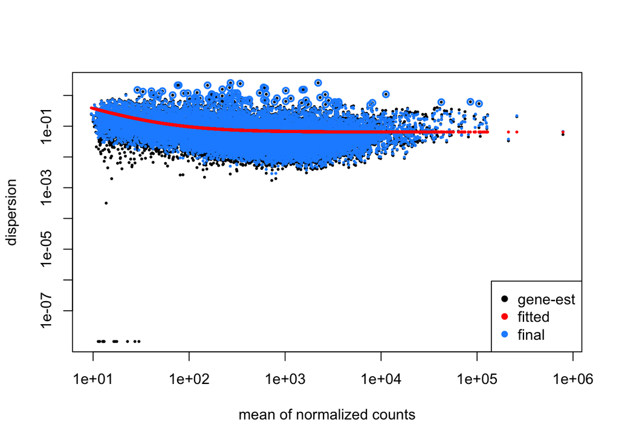

```r
plotDispEsts(cds)
```

```r
#The graph shows an even, high dispersion indicating small mean counts and that
#the data is a good fit for the model
```

### Step 5 (5pts)

Perform the Differential expression and obtain the results using **DESeq** and **results** functions.

```r
cds = DESeq(cds)
```

```
## found already estimated dispersions, replacing these
```

```
## -- replacing outliers and refitting for 128 genes
## -- DESeq argument 'minReplicatesForReplace' = 7
## -- original counts are preserved in counts(dds)
```

```r
resultsNames(cds)
```

```
## [1] "Intercept"                   "condition_vec_Healthy_vs_CF"
```

```r
results = results(cds, name = 'condition_vec_Healthy_vs_CF')
```

### Step 6 (5pts)

How many genes have an adjusted p-value of less than 0.05 and log2FoldChange greater than 1 or less than -1 ? Save this list of genes as **diffexpgenes**

```r
dim(subset(results, padj < 0.05 & log2FoldChange > 1))
```

```
## [1] 17  6
```

```r
dim(subset(results, padj < 0.05 & log2FoldChange < -1))
```

```
## [1] 192   6
```

```r
# 17 genes have an adjusted p-value of less than 0.05 and log2FoldChange greater than 1
# 192 genes have an adjusted p-value of less than 0.05 and log2FoldChange less than -1
diffexpgenes = subset(results, padj < 0.05 & (log2FoldChange > 1 | log2FoldChange < -1))
```

### Step 7 (5pts)

Get the normalized values of the counts data in cds using the counts() function with option normalized=T and call this normvalues.

```r
normvalues = counts(cds,normalized=TRUE)
```

### Step 8 (5pts)

Create a new matrix or dataframe that contains the expression values from normvalues for just the diffexpgenes and call it diffexpvalues.

```r
diffexpgenes_df = as.data.frame(diffexpgenes)
diffexpvalues = normvalues[rownames(normvalues) %in% rownames(diffexpgenes_df), ]
```

### Step 9 (10pts)

Cluster the differentially expressed genes using hierarchical clustering and use the cutree function to create 8 groups. How many genes are in each group?

```r
dist = dist(diffexpgenes_df)
tree = hclust(dist)
clusters = cutree(tree,k = 8)
clusters_df = as.data.frame(clusters)

group_by(clusters_df, clusters) %>% summarize(count=n())
```

```
## # A tibble: 8 × 2
##   clusters count
##      <int> <int>
## 1        1   184
## 2        2     1
## 3        3     3
## 4        4    16
## 5        5     1
## 6        6     2
## 7        7     1
## 8        8     1
```

```r
# 184 in group 1, 1 in group 2, 3 in group 3, 16 in group 4, 1 in group 5,
# 2 in group 6, 1 in groups 7 and 8.
```

### Step 10 (10pts)

Create a heatmap of all the genes using the **pheatmap** package. Some options you should pay attention to are: - scale ( scaling gene values shows expression pattern changes rather than magnitude) - cluster_rows ( define how the rows should be clustered) - annotation_col ( color code the different samples based on a category- health or cf) - annotation_row ( color code the different genes based on the cluster they belong to)

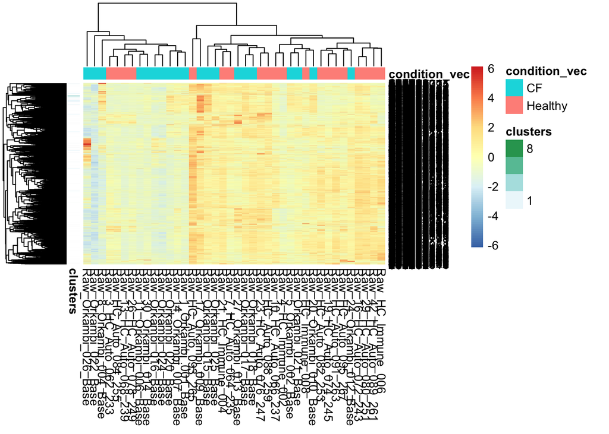

```r
library('pheatmap')
pheatmap(readcount, scale = 'row', cluster_rows = TRUE, annotation_col= expgroup, annotation_row= clusters_df)
```

### Step 11 (10pts)

Use the GOstats package to determing which GO-terms are enriched in **diffexpgenes**. To do this you will need to install the following packages from Bioconductor:

```r
BiocManager::install("GOstats")
BiocManager::install("GO.db")
BiocManager::install("Category")
BiocManager::install("org.Hs.eg.db")
```

```r
library('GOstats')
library('Category')
library("org.Hs.eg.db")
library('annotate')
library('GO.db')
```

Now create a new **GOHyperGParams** object using the **new()** function and save it as variable called **params**. The **geneIds** is **diffexpgenes**. These should be the EntrezIDs we made into rownames in the beginning. The **universeGeneIds** is the rownames of **readcount**. The annotation is **org.Hs.eg** and the ontology we are going to use is **BP** with a pvaluecutoff of 0.001 and our testDirection is **over**.

```r
params = new('GOHyperGParams',geneIds = rownames(diffexpgenes_df), universeGeneIds = rownames(readcount), annotation = "org.Hs.eg.db", ontology = 'BP', pvalueCutoff = 0.001, testDirection = 'over')
summary(hyperGTest(params))
```

```
##        GOBPID       Pvalue OddsRatio   ExpCount Count Size
## 1  GO:0009605 2.216615e-10  2.909650 27.8480631    62 1689
## 2  GO:0006952 9.620572e-10  3.243182 17.1309281    45 1039
## 3  GO:0006955 2.525361e-09  3.028491 19.6370889    48 1191
## 4  GO:0006954 3.729980e-09  4.111712  8.3428774    29  506
## 5  GO:0002526 1.105159e-07 11.200284  1.0882014    10   66
## 6  GO:0002376 3.344791e-07  2.372400 29.6617321    57 1799
## 7  GO:0032501 4.111008e-07  2.101614 68.6721035   102 4165
## 8  GO:0009607 4.603816e-07  2.806150 15.4821381    37  939
## 9  GO:0032101 5.923851e-07  3.174950 10.5357681    29  639
## 10 GO:0043207 6.023301e-07  2.810172 14.9875011    36  909
## 11 GO:0051707 6.023301e-07  2.810172 14.9875011    36  909
## 12 GO:0098542 1.421084e-06  3.027504 10.9974293    29  667
## 13 GO:0044419 1.561429e-06  2.617831 16.9660491    38 1029
## 14 GO:0009617 1.625392e-06  3.720386  6.3973052    21  388
```

[output cut: 159 more lines]

### Step 12 (5pts)

What conclusions can you make about your analysis?

[output not shown]